# Plotting Time Series Statistics with ggplot2 and ggfortify

This document explains plotting time series statistics using `ggplot2` and `ggfortify`.

# Installation

First, install `ggfortify` from [github](https://github.com/sinhrks/ggfortify).

```r
library(devtools)
install_github('sinhrks/ggfortify')
```

# Plotting time series statistics

`ggfortify` supports following time series related statistics in `stats` package:

- `stl`, `decomposed.ts`
- `acf`, `pacf`, `ccf`
- `spec.ar`, `spec.pgram`
- `cpgram` (covered by `ggcpgram`)

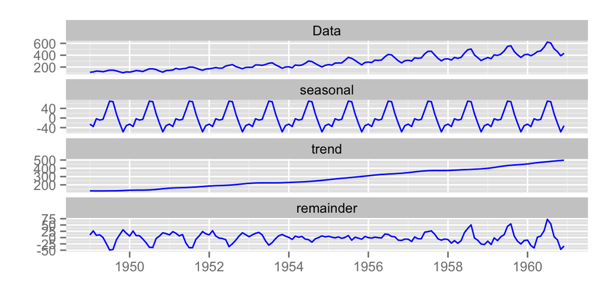

```r
library(ggplot2)
library(ggfortify)
autoplot(stl(AirPassengers, s.window = 'periodic'), ts.colour = 'blue')
```

**NOTE** With `acf` and `spec.*`, specify `plot = FALSE` to suppress default plotting outputs.

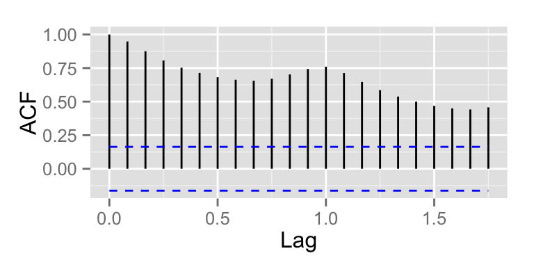

```r
autoplot(acf(AirPassengers, plot = FALSE))
```

You can pass some options when plotting `acf` via `autoplot`. Built-in `acf` calcurates the confidence interval at plotting time and doesn’t hold the result, equivalent options can be passed to `autoplot`. Following example shows to change the value of confidence interval and method (use `ma` assuming the input follows MA model).

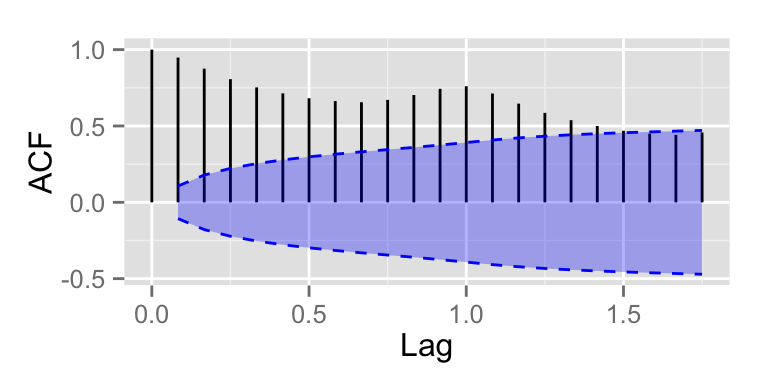

```r
autoplot(acf(AirPassengers, plot = FALSE), conf.int.fill = '#0000FF', conf.int.value = 0.8, conf.int.type = 'ma')
```

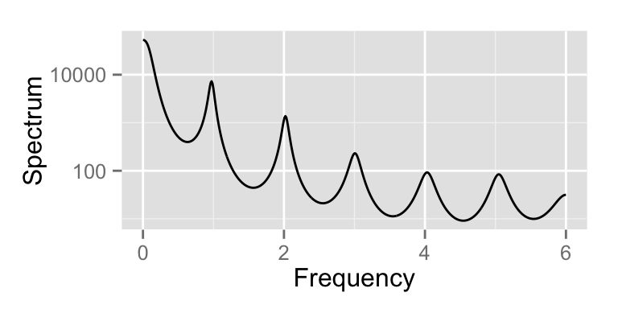

```r
autoplot(spec.ar(AirPassengers, plot = FALSE))
```

`ggcpgram` should output the cumulative periodogram as the same as `cpgram`. Because `cpgram` doesn’t have return value, we cannot use `autoplot(cpgram(...))`.

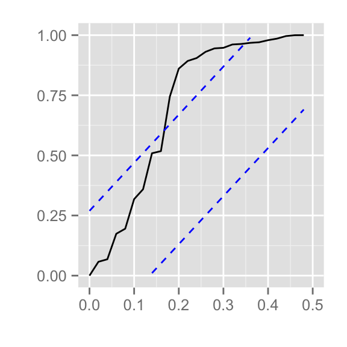

```r
ggcpgram(arima.sim(list(ar = c(0.7, -0.5)), n = 50))
```

`ggtsdiag` should output the similar diagram as `tsdiag`.

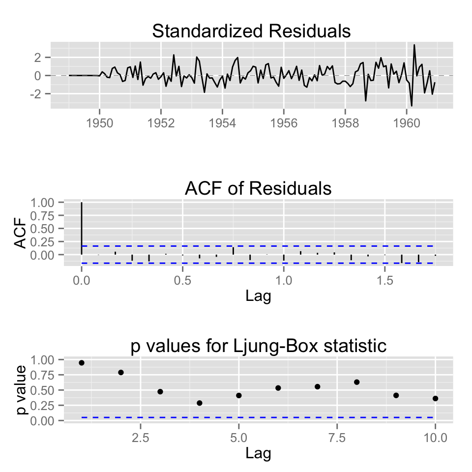

```r
library(forecast)
ggtsdiag(auto.arima(AirPassengers))
```

`gglagplot` is for `lag.plot`.

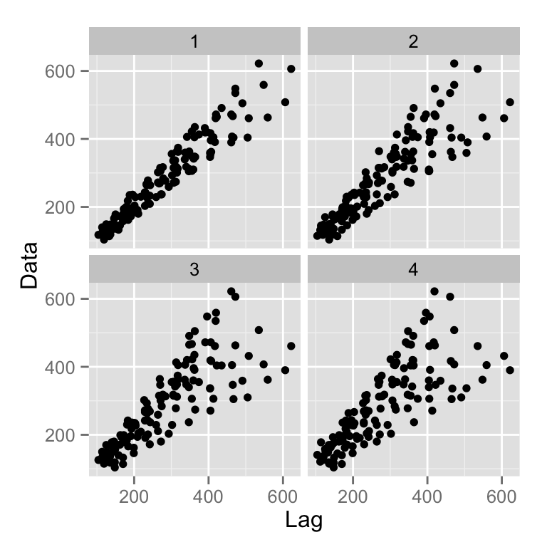

```r
gglagplot(AirPassengers, lags = 4)
```

`ggfreqplot` is a genelarized `month.plot`. You can pass `freq` if you want, otherwise time-series’s frequency will be used.

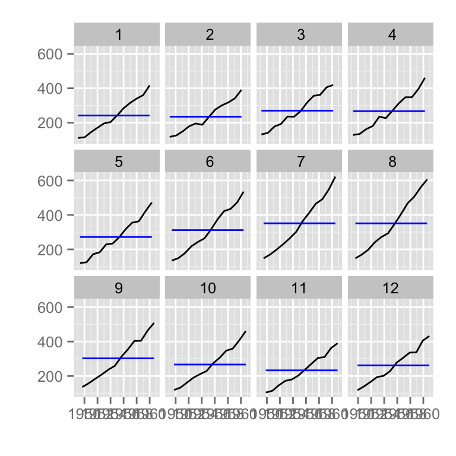

```r
ggfreqplot(AirPassengers)
```

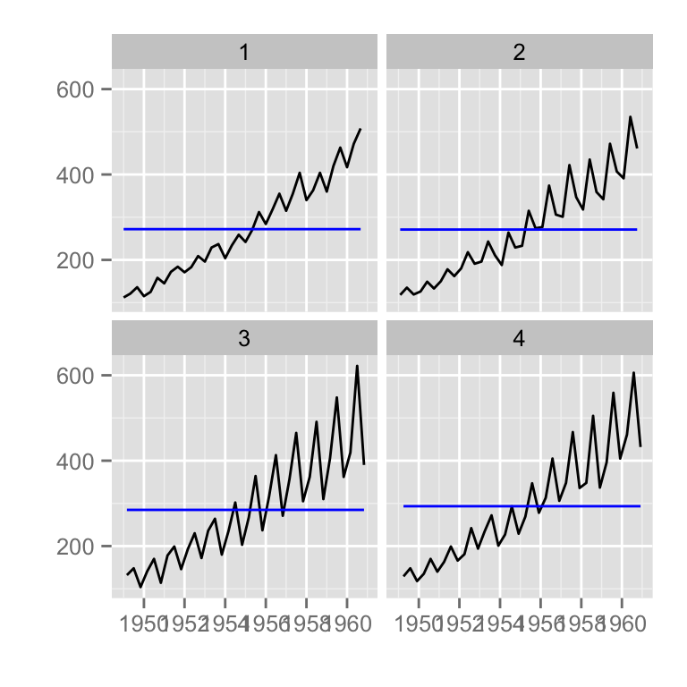

```r
ggfreqplot(AirPassengers, freq = 4)
```

# Resources related to ggfortify

- [Plotting Time Series with ggplot2 and ggfortify](http://rpubs.com/sinhrks/plot_ts)
- [Plotting Time Series Statistics with ggplot2 and ggfortify](http://rpubs.com/sinhrks/plot_tsstats)
- [Plotting PCA/clustering results using ggplot2 and ggfortify](http://rpubs.com/sinhrks/plot_pca)
- [Plotting Survival Curves using ggplot2 and ggfortify](http://rpubs.com/sinhrks/plot_surv)
- [Plotting Probability Distributions with ggplot2 and ggfortify](http://rpubs.com/sinhrks/plot_dist)